# AI Race Engineer Copilot — Scuderia Tor Vergata

## AI Race Engineer Copilot

SCUDERIA TOR VERGATA

Un assistente per l’ingegnere di pista,  
costruito su OCI Enterprise AI

Team Struffoli  
Valerio Bernardi · Alfredo Grande  
Samuele De Santis · Luca Gugliotta

[figure not shown]

[figure not shown]

[figure not shown]

[figure not shown]

HACKATHON CON ORACLE · 22/05/2026

## Obiettivo del progetto

01 OBIETTIVO

Un chatbot operativo a supporto della Scuderia Tor Vergata.

[figure not shown]

Contesto real-time

Analisi immediata dei dati di gara e del regolamento.

[figure not shown]

Riduzione delle allucinazioni

Esposizione esclusiva di dati e numeri effettivamente recuperati.

[figure not shown]

Incertezza dichiarata

Assenza di informazioni notificata esplicitamente all’utente.

[figure not shown]

Scuderia Tor Vergata · box e pit lane

## Due fonti, due formati

01 FONTI E DATI

01 DATI DI GARA

[figure not shown]

### Telemetria

Dati dinamici sulle condizioni del veicolo a ogni pit di gara.

JSON

02 DOCUMENTI

[figure not shown]

### Regolamento

Dossier tecnico e normativo per le verifiche dei veicoli in gara.

PDF

## Task progettuali

01 GLI OBIETTIVI

L’architettura del copilota sviluppata in tre task.

01 TASK 1

[figure not shown]

### Server MCP

Sviluppo di tool di estrazione per analizzare i dati JSON della telemetria.

02 TASK 2

[figure not shown]

### RAG normativo

Chunking dei PDF e verifica della conformità tramite ricerca semantica.

03 TASK 3

[figure not shown]

### App unificata

Collegamento del chatbot con server e RAG, e web app Streamlit per porre query all’assistente.

## Un LLM da solo non basta

02 PERCHÉ UN SISTEMA

Perché non mettere tutto nel prompt?

Abbiamo **due fonti di informazione molto diverse**: metterle tutte nel prompt renderebbe il sistema poco efficiente e poco controllabile.

[figure not shown]

Telemetria

[figure not shown]

Documenti

[figure not shown]

Token sprecati

Context window piena di dati inutili

[figure not shown]

Poco controllo

Il modello cerca da solo nel contesto

[figure not shown]

Valori inventati

Calcoli approssimativi e regole non verificate

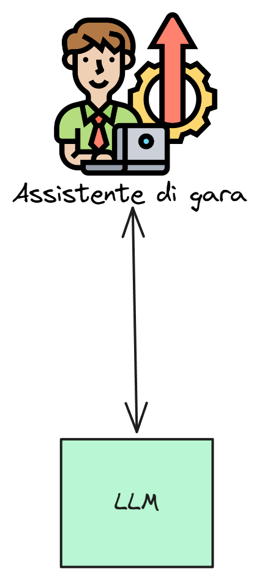

## Costruire un harness attorno all’LLM

02 LA SOLUZIONE

Il modello non è più un chatbot.

[figure not shown]

Orchestratore

L’LLM coordina gli strumenti e ragiona

[figure not shown]

Tool dedicati

MCP + File Search

[figure not shown]

Separazione dei compiti

LLM e tool con responsabilità distinte

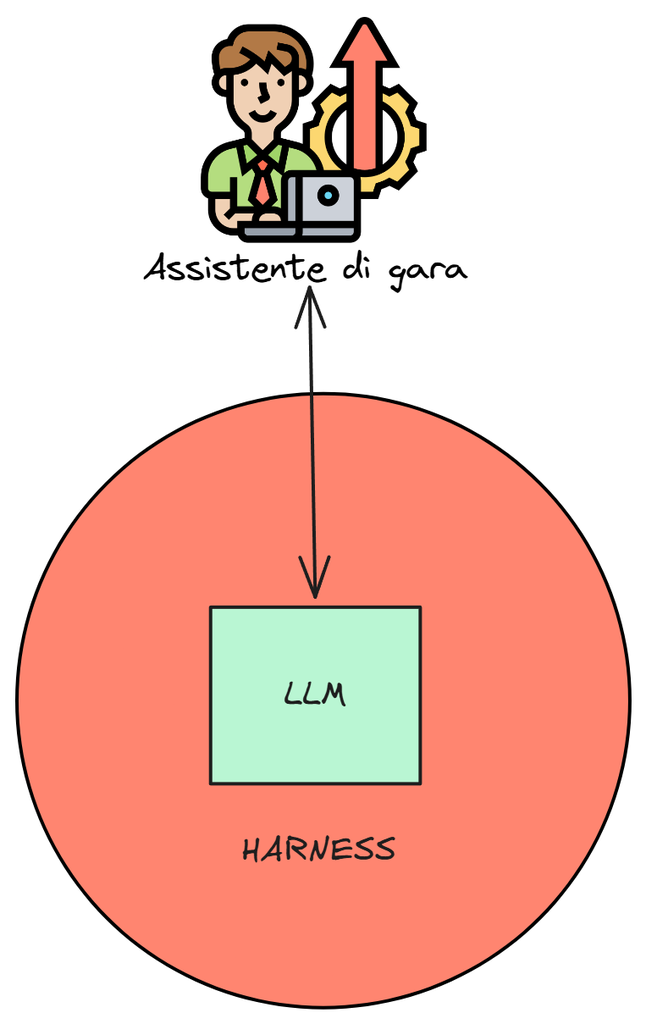

## Una richiesta, due percorsi

02 ARCHITETTURA

[figure not shown]

[figure not shown]

OCI Generative AI

Riceve dal client, via Responses API, il prompt dell’utente e gli strumenti disponibili.

[figure not shown]

Tool calling

Il modello decide quali strumenti utilizzare, anche più volte nello stesso flusso. Per la telemetria invoca i tool esposti dal server MCP.

[figure not shown]

`file_search`

Tool di retrieval: recupera dall’OCI Vector Store i passaggi più rilevanti per la richiesta.

[figure not shown]

ngrok

Tunnel HTTPS: rende il server MCP locale raggiungibile da OCI Generative AI nel cloud.

## I due strumenti: MCP e OCI Vector Store

02 TECNOLOGIE

01 DATI DI GARA

[figure not shown]

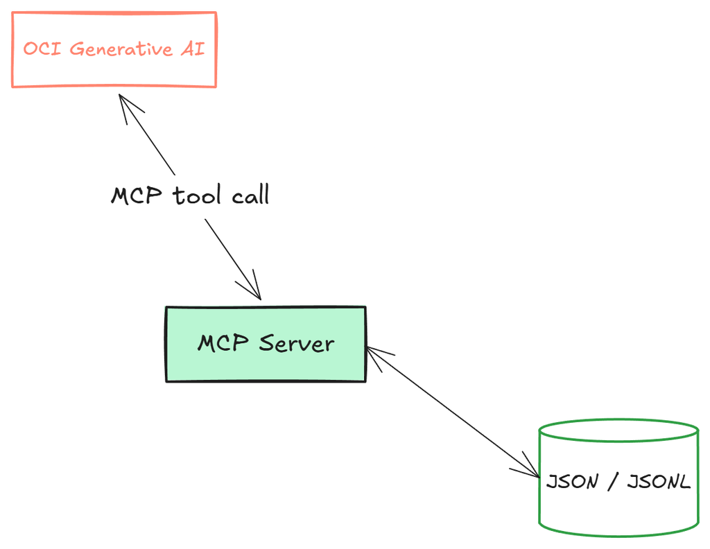

### MCP Server

Espone tool per accedere in modo **controllato** a dati esterni.

- Telemetria in **JSON / JSONL**
- Fornisce uno standard per l’integrazione dei tool con gli LLM
- Comunicazione mediante Model Context Protocol

02 DOCUMENTI

[figure not shown]

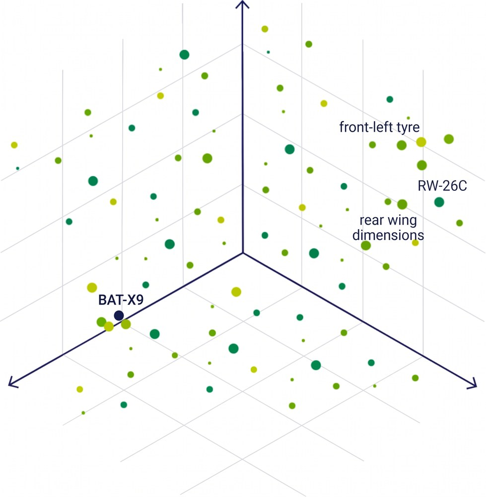

### OCI Vector Store

Embedding e ricerca semantica sui documenti.

- Ogni chunk diventa un **vettore multidimensionale**
- Significati simili → vettori **vicini nello spazio**
- **Ricerca semantica** tramite `file_search`
- Embedding e retrieval gestiti da OCI

## I tool MCP

03 IMPLEMENTAZIONE

mcp-server-struffoli.py TASK 1

```python
@mcp.tool()
def get_lap_window(start_lap: int,
                   end_lap: int) -> Dict[str, Any]:
    """Return a list of lap records between
    start_lap and end_lap, inclusive."""
    meta = _load_json("race_session_telemetry.json")
    result = []
    for lap in meta["laps"]:
        if start_lap <= lap["lap"] <= end_lap:
            result.append(lap)
    return {
        "start_lap": start_lap,
        "end_lap": end_lap,
        "laps_found": len(result),
        "laps": result
    }
```

**Implementazione dell’MCP tool richiesto dal Task 1:** `get_lap_window`

mcp-server-struffoli.py TASK 3

```python
@mcp.tool()
def recommend_pit_strategy(
        current_lap: int) -> Dict[str, Any]:
    """Analizza strategia e usura per raccomandare
    il momento ottimale del pit stop e stimarne
    l'impatto sulla gara."""
    # calcolo deterministico
    laps_to_limit = (95.0 - current_wear) / deg_rate
    ...
    return {"recommendation": "PIT_IN_WINDOW",
            "target_pit_lap": 27, ...}
```

**Implementazione di un MCP tool aggiunto per l’interfaccia (Task 3):** `recommend_pit_strategy`

## L’OCI Vector Store

03 OCI VECTOR STORE

upload_file.py PYTHON

```python
chunks = chunk_pdf_per_ai(pdf_path,
                          chunk_size=1500, overlap=200)
for i, chunk in enumerate(chunks):
    f = client.files.create(file=to_file(chunk),
                            purpose="user_data")
    client.vector_stores.files.create(
        vector_store_id=VECTOR_STORE_ID, file_id=f.id,
        attributes={"original_file": name,
                    "chunk_index": i})
```

**Caricamento dei file**, divisi in chunk, nel Vector Store.

I file vengono divisi in **chunk di dimensione fissa**, per evitare di superare i limiti di memoria per file imposti dal Vector Store.

1500 caratteri per chunk

200 caratteri di overlap

## Prompt Engineering

03 IMPLEMENTAZIONE

system prompt PROMPT

```
You are an AI Race Engineer Copilot for Scuderia Tor Vergata.
You combine two main capabilities:
1. Race telemetry and strategy analysis through MCP tools.
2. Regulatory compliance and dossier analysis via file_search.
...
Do not guess.
Use MCP tools for structured race data.
Use file_search for regulations, rulebooks, technical dossiers.
If evidence is missing, incomplete or ambiguous, say so explicitly.
Never invent:
- telemetry values
- lap data
...
For every answer, explicitly state which evidence source was used:
- MCP only
- file_search only
- MCP + file_search
- No tool evidence available
...
For compliance answers, provide a documentation support score:
how strongly the available documents support your answer,
NOT how legally compliant the component is.
```

REGOLE DEL COPILOTA

- Non inventare dati quando non sei sicuro della risposta
- Affidati ai tool MCP e `file_search`
- Dichiara il peso attribuito a ciascuna fonte
- Mostra il ragionamento step by step che farebbe un ingegnere di gara

## L’interfaccia del Race Engineer

04 TASK 3 · DEMO

Una dashboard Streamlit per consultare i dati di gara, interrogare l’assistente e caricare documenti tecnici.

[video not shown]

interfaccia.py PYTHON

```python
tab1, tab2, tab3 = st.tabs(
    ["Lap time", "Energy", "Position"])

with tab1:
    if ("lap_time_s" in df.columns
            and df["lap_time_s"].notna().any()):
        chart_df = (df.set_index("lap")
                    [["lap_time_s"]])
        st.line_chart(chart_df, height=180)
```

**Un tab per grafico:** tempi, energia, posizione.

## Dalla quick action alla risposta

04 DEMO · TELEMETRIA

I dati della gara vengono recuperati tramite MCP e trasformati in una risposta operativa.

[video not shown]

ANDATA

- Streamlit
- client Python
- OCI Responses API
- strumenti MCP

RITORNO

- risultati MCP
- OCI Responses API
- client Python
- chat Streamlit

## Verifica documentale BAT-X9

04 DEMO · REGOLAMENTO

Un secondo percorso per il modello: file_search apre l’accesso ai documenti.

[video not shown]

ANDATA

- Streamlit
- client Python
- OCI Responses API
- `file_search` → documenti

RITORNO

- passaggi recuperati
- OCI Responses API
- client Python
- chat Streamlit

## La fonte dipende dalla domanda

04 RISULTATI

Una sola Responses API, due percorsi di evidenza.

01 TELEMETRIA

[figure not shown]

### Analisi dello pneumatico e pit stop

100% MCP

0% file_search

DATO Usura **61,4 %** contro **43,1 %** atteso

RISPOSTA Sosta proposta tra i giri **24 e 27**

02 REGOLAMENTO

[figure not shown]

### Verifica BAT-X9

100% file_search

0% MCP

DOCUMENTO TROVATO Dossier BAT-X9

RISPOSTA Conformità non confermata: norma decisiva non recuperata

## Dalla telemetria al post social

04 DEMO · COMUNICAZIONE

I dati in gara alimentano anche la comunicazione.

[video not shown]

`get_session_overview` → ultimo giro

`get_lap_window` → ultimi 5 giri

**Dati di gara → bozza del post**

## Grazie mille dell’attenzione

05 CONCLUSIONI

Grazie mille  
dell’attenzione

Team Struffoli

Valerio Bernardi · Alfredo Grande  
Samuele De Santis · Luca Gugliotta

Scuderia Tor Vergata

[figure not shown]

Team Struffoli · Scuderia Tor Vergata